# Diabetes Care

Shan Wang

03 February, 2020

# 1 Loading and Exploring the Data Set

Let us first read the data set from the file.

```r
quality = read.csv("Diabetes.csv")
str(quality)
```

```
## 'data.frame':    131 obs. of  14 variables:
##  $ MemberID            : int  1 2 3 4 5 6 7 8 9 10 ...
##  $ InpatientDays       : int  0 1 0 0 8 2 16 2 2 4 ...
##  $ ERVisits            : int  0 1 0 1 2 0 1 0 1 2 ...
##  $ OfficeVisits        : int  18 6 5 19 19 9 8 8 4 0 ...
##  $ Narcotics           : int  1 1 3 0 3 2 1 0 3 2 ...
##  $ DaysSinceLastERVisit: num  731 411 731 158 449 ...
##  $ Pain                : int  10 0 10 34 10 6 4 5 5 2 ...
##  $ TotalVisits         : int  18 8 5 20 29 11 25 10 7 6 ...
##  $ ProviderCount       : int  21 27 16 14 24 40 19 11 28 21 ...
##  $ MedicalClaims       : int  93 19 27 59 51 53 40 28 20 17 ...
##  $ ClaimLines          : int  222 115 148 242 204 156 261 87 98 66 ...
##  $ StartedOnCombination: logi  FALSE FALSE FALSE FALSE FALSE FALSE ...
##  $ AcuteDrugGapSmall   : int  0 1 5 0 0 4 0 0 0 0 ...
##  $ PoorCare            : int  0 0 0 0 0 1 0 0 1 0 ...
```

*MemberID* is the unique identifier that numbers patients from 1 to 131. *InpatientDays* is the number of inpatient visits or the number of days that the patient spent in the hospital. *ERVisits* is the number of times the patient visited the emergency room. *OfficeVisits* is the number of times that the patient visited any doctor’s office. *Narcotics* is the number of prescriptions that the patient had for narcotics. *DaysSinceLastERVisit* is the number of days between the patient’s last emergency room (ER) visit and the end of the study period, and it is set to the length of the study period if they never visited the ER. *Pain* is the number of visits for which the patient complained about pain. *TotalVisits* is the total number of times the patient visited any healthcare provider. *ProviderCount* is the number of providers that served the patient. *MedicalClaims* is the number of days on which the patient had a medical claim. *ClaimLines* is the total number of medical claims. *StartedOnCombination* is whether or not the patient was started on a combination of drugs to treat their diabetes. *AcuteDrugGapSmall* is the fraction of acute drugs that were refilled quickly after the prescription ran out. *PoorCare* is the dependent variable, and is equal to 1 if the patient had poor care, and equal to 0 if the patient had good care.

We can see how many patients received poor care and how many patients received good care by using the ‘table’ function.

```r
table(quality$PoorCare)
```

```
##
##  0  1
## 98 33
```

The percentage of patients received poor care can be computed as follows.

```r
percPC = sum(quality$PoorCare)/nrow(quality)
percPC
```

```
## [1] 0.2519084
```

You can see from the output of the ‘str’ function that the variable *PoorCare* is of ‘int’ type, which stands for integer. By default, R treats numbers in the data file according to the type that it was recorded. In this case, since *PoorCare* is recorded as 0 or 1 in the data file, it is treated as a numerical variable, in particular, an integer variable. For numerical variables, we can use the ‘summary’ function to take a look at some of its statistics.

```r
summary(quality$PoorCare)
```

```
##    Min. 1st Qu.  Median    Mean 3rd Qu.    Max.
##  0.0000  0.0000  0.0000  0.2519  0.5000  1.0000
```

However, in our case, *PoorCare* should be treated as a categorical variable, i.e., ‘Factor’ variable type in R. The type of variable will make a big difference in the way that R handles the variable. We can convert its type to ‘Factor’ using the following command.

```r
quality$PoorCare = as.factor(quality$PoorCare)
str(quality)
```

```
## 'data.frame':    131 obs. of  14 variables:
##  $ MemberID            : int  1 2 3 4 5 6 7 8 9 10 ...
##  $ InpatientDays       : int  0 1 0 0 8 2 16 2 2 4 ...
##  $ ERVisits            : int  0 1 0 1 2 0 1 0 1 2 ...
##  $ OfficeVisits        : int  18 6 5 19 19 9 8 8 4 0 ...
##  $ Narcotics           : int  1 1 3 0 3 2 1 0 3 2 ...
##  $ DaysSinceLastERVisit: num  731 411 731 158 449 ...
##  $ Pain                : int  10 0 10 34 10 6 4 5 5 2 ...
##  $ TotalVisits         : int  18 8 5 20 29 11 25 10 7 6 ...
##  $ ProviderCount       : int  21 27 16 14 24 40 19 11 28 21 ...
##  $ MedicalClaims       : int  93 19 27 59 51 53 40 28 20 17 ...
##  $ ClaimLines          : int  222 115 148 242 204 156 261 87 98 66 ...
##  $ StartedOnCombination: logi  FALSE FALSE FALSE FALSE FALSE FALSE ...
##  $ AcuteDrugGapSmall   : int  0 1 5 0 0 4 0 0 0 0 ...
##  $ PoorCare            : Factor w/ 2 levels "0","1": 1 1 1 1 1 2 1 1 2 1 ...
```

Now, if we apply the ‘summary’ function on *PoorCare*, it will be handled differently. No statistics will be computed because it is not a number now. What you will see is count for each possible outcome, called factor level in R.

```r
summary(quality$PoorCare)
```

```
##  0  1
## 98 33
```

# 2 Baseline Model for Predicting Patients Receiving Good Care

The baseline model for such a classification problem is to just predict the most frequent outcome for all observations. Since good care is more common than poor care, we would predict that all patients are receiving good care, which gives us an accuracy of 74.81%.

# 3 Splitting the Data Set for Training and Testing

It is a good practice to train and test any models using different data sets as we have done before. In this case, we only have one data set, so the common practice is to randomly split the data set into a training set and a test set, where the test set is used to measure the out-of-sample accuracy of our model.

To do this, we need to add a new package to R. There are many functions and algorithms built into R, but there are many more that you can install. We will do this several times throughout this course. In the Rstudio interface, you can type in Console to install any packages. Let us type ‘install.packages(“caTools”)’ and hit Enter.

Now we are ready to load the package into our current R session by using the command ‘library(caTools)’.

```r
library(caTools)
```

Now, let us use this package to randomly split our data into a training set and a test set. We will do this by using a function called ‘sample.split’, which is part of the “caTools” package. Since this function randomly splits your data, it could split it differently for each of us. To make sure that we all get the same split, we can set our seed to the same number. The seed initializes the random number generator. This is important not only to make sure we all get the same results later but also to make it easier to check your work in the future. Otherwise, if you do not set the seed, everytime when you run your code and regenerate the results, you will get different numbers, which can make debugging and model improvement very challenging. We will use this feature again and again in this course and you will be very familiar with it.

```r
set.seed(123)
split = sample.split(quality$PoorCare, SplitRatio = 0.70)
split
```

```
##   [1]  TRUE FALSE  TRUE FALSE FALSE  TRUE  TRUE  TRUE  TRUE FALSE  TRUE
##  [12]  TRUE FALSE  TRUE  TRUE  TRUE  TRUE  TRUE FALSE  TRUE  TRUE  TRUE
##  [23]  TRUE  TRUE FALSE FALSE  TRUE FALSE  TRUE FALSE  TRUE FALSE  TRUE
##  [34] FALSE FALSE  TRUE  TRUE  TRUE  TRUE FALSE  TRUE FALSE  TRUE FALSE
##  [45]  TRUE  TRUE  TRUE FALSE  TRUE FALSE  TRUE  TRUE  TRUE  TRUE  TRUE
##  [56]  TRUE  TRUE  TRUE  TRUE  TRUE  TRUE FALSE  TRUE FALSE  TRUE  TRUE
##  [67] FALSE  TRUE  TRUE FALSE  TRUE  TRUE  TRUE  TRUE FALSE FALSE  TRUE
##  [78]  TRUE  TRUE  TRUE  TRUE FALSE  TRUE  TRUE FALSE  TRUE FALSE FALSE
##  [89] FALSE  TRUE FALSE  TRUE FALSE  TRUE  TRUE  TRUE  TRUE  TRUE  TRUE
## [100]  TRUE  TRUE  TRUE FALSE  TRUE  TRUE  TRUE  TRUE  TRUE  TRUE FALSE
## [111]  TRUE  TRUE FALSE  TRUE  TRUE  TRUE  TRUE FALSE FALSE FALSE  TRUE
## [122]  TRUE  TRUE  TRUE FALSE  TRUE  TRUE  TRUE FALSE  TRUE  TRUE
```

The first argement in the ‘sample.split’ function makes sure that in the training set, around 25.19% of the patients received poor care, and in the test set 25.19% of the patients received poor care. In other words, the *PoorCare* variable is balanced in training and test sets. We want to do this so that our test set is representative of the training set.

The split function creates a TRUE or FALSE value for each of our observations. TRUE means that we should put that observation in the training set, and FALSE means that we should put that observation in the test set. Now let us create the training and test sets using the ‘subset’ function.

```r
qualityTrain = subset(quality, split == TRUE)
qualityTest = subset(quality, split == FALSE)
```

We can check the number of data points in the training set and the test set, and confirm that the fractions of patients who received poor care are indeed similar to the whole dataset.

```r
table(qualityTrain$PoorCare)
```

```
##
##  0  1
## 69 23
```

```r
table(qualityTest$PoorCare)
```

```
##
##  0  1
## 29 10
```

# 4 Building a Logistic Regression Model

Now, we are ready to build a logistic regression model using *OfficeVisits* and *Narcotics* as independent variables, similar to building a linear regression model. In the code below, we use the function, ‘glm,’ which stands for generalized linear model. The argument, *family = binomial*, indicates that we are trying to predict two possible outcomes so that the logistic regression model will be called from the class of generalized linear models.

```r
QualityLog = glm(PoorCare ~ OfficeVisits + Narcotics, data = qualityTrain, family = binomial)
summary(QualityLog)
```

```
##
## Call:
## glm(formula = PoorCare ~ OfficeVisits + Narcotics, family = binomial,
##     data = qualityTrain)
##
## Deviance Residuals:
##     Min       1Q   Median       3Q      Max
## -2.3483  -0.5824  -0.4584  -0.2302   2.1552
##
## Coefficients:
##              Estimate Std. Error z value Pr(>|z|)
## (Intercept)  -2.84649    0.60526  -4.703 2.56e-06 ***
## OfficeVisits  0.07720    0.03283   2.352  0.01870 *
## Narcotics     0.10613    0.03699   2.869  0.00411 **
## ---
## Signif. codes:  0 '***' 0.001 '**' 0.01 '*' 0.05 '.' 0.1 ' ' 1
##
## (Dispersion parameter for binomial family taken to be 1)
##
##     Null deviance: 103.470  on 91  degrees of freedom
## Residual deviance:  75.674  on 89  degrees of freedom
## AIC: 81.674
##
## Number of Fisher Scoring iterations: 5
```

The model output is also similar to a linear regression model. The AIC value is a measure of the quality of the model and is like the adjusted R-squared in that it accounts for the number of variables used compared to the number of observations. It provides a means for model selection, but one can only use it to compare models built on the same data set. The preferred model is the one with the minimum AIC. The last line has to do with the algorithm (Newton-Raphson algorithm or Newton’s Method by default) that is used to find the coefficients (through solving an optimization problem). This information on AIC will be tested.

# 5 In-Sample Model Validation

## 5.1 Sensitivity and Specificity(Recall)

We can now make predictions on the training set. The argument *type = “response”* in the code below makes sure that the algorithm uses the logistic response function to compute the predictions, which should be numbers between 0 and 1. You can try removing this argument and see what you get.

```r
predictTrain = predict(QualityLog, type = "response")
summary(predictTrain)
```

```
##    Min. 1st Qu.  Median    Mean 3rd Qu.    Max.
## 0.05486 0.09932 0.13446 0.25000 0.26498 0.99623
```

Let us take a look at the predicted probabilities of receiving poor care for the first ten patients in the training set, and compare them to the actual observations.

```r
predictTrain[1:10]
```

```
##          1          3          6          7          8          9
## 0.20574139 0.10506987 0.12570812 0.10690266 0.09718481 0.09802901
##         11         12         14         15
## 0.25156838 0.13220566 0.27207140 0.46631314
```

```r
qualityTrain$PoorCare[1:10]
```

```
##  [1] 0 0 1 0 0 1 0 0 0 0
## Levels: 0 1
```

Note that the indices in the display of the first ten elements in *predictTrain* correspond to the indices of patients in the original data frame before random splitting into the training and test sets. You can confirm this by referring the output from displaying *split* in the above code chunk.

Let us see if the model is predicting higher probabilities for the actual poor care cases as we expect.

```r
tapply(predictTrain, qualityTrain$PoorCare, mean)
```

```
##         0         1
## 0.1691589 0.4925233
```

If we use 0.5 as the threshold, we get the following confusion matrix.

```r
conf05 = table(qualityTrain$PoorCare, predictTrain > 0.5)
conf05
```

```
##
##     FALSE TRUE
##   0    66    3
##   1    13   10
```

You can see here that for 66 cases, we predict good care, and they received good care; and for 10 cases, we predict poor care, and they received poor care. We make 3 mistakes where we say poor care, but care was good, and we make 13 mistakes where we say good care, but the care was poor. The accuracy of the prediction using 0.5 as the threshold is 76/92 = 82.61%.

We can compute the sensitivity, or the true positive rate, which equals to 10/23 = 0.43, and the specificity, or the true negative rate, which equals to 66/69 = 0.96.

Let us try increasing the threshold.

```r
conf07 = table(qualityTrain$PoorCare, predictTrain > 0.7)
conf07
```

```
##
##     FALSE TRUE
##   0    68    1
##   1    14    9
```

Now the sensitivity equals to 9/23 = 0.39, and the specificity equals to 68/69 = 0.99. By increasing the threshold, our sensitivity goes down, and our specificity goes up. We can also try decreasing the threshold.

```r
conf02 = table(qualityTrain$PoorCare, predictTrain > 0.2)
conf02
```

```
##
##     FALSE TRUE
##   0    51   18
##   1     7   16
```

Now the sensitivity equals to 16/23 = 0.7 and the specificity equals to 51/69 = 0.74. By decreasing the threshold, our sensitivity goes up, and our specificity goes down.

## 5.2 Receiver Operating Characteristic (ROC) Curves

To generate receiver operating characteristic (ROC) curves in R, we need to install a new package, called “ROCR.” As before, you can type ‘install.packages(“ROCR”)’ in the Console, and then load the package using the ‘library’ function.

```r
library(ROCR)
```

Recall that we made predictions on our training set and called them *predictTrain*. We will use these predictions to create our ROC curve.

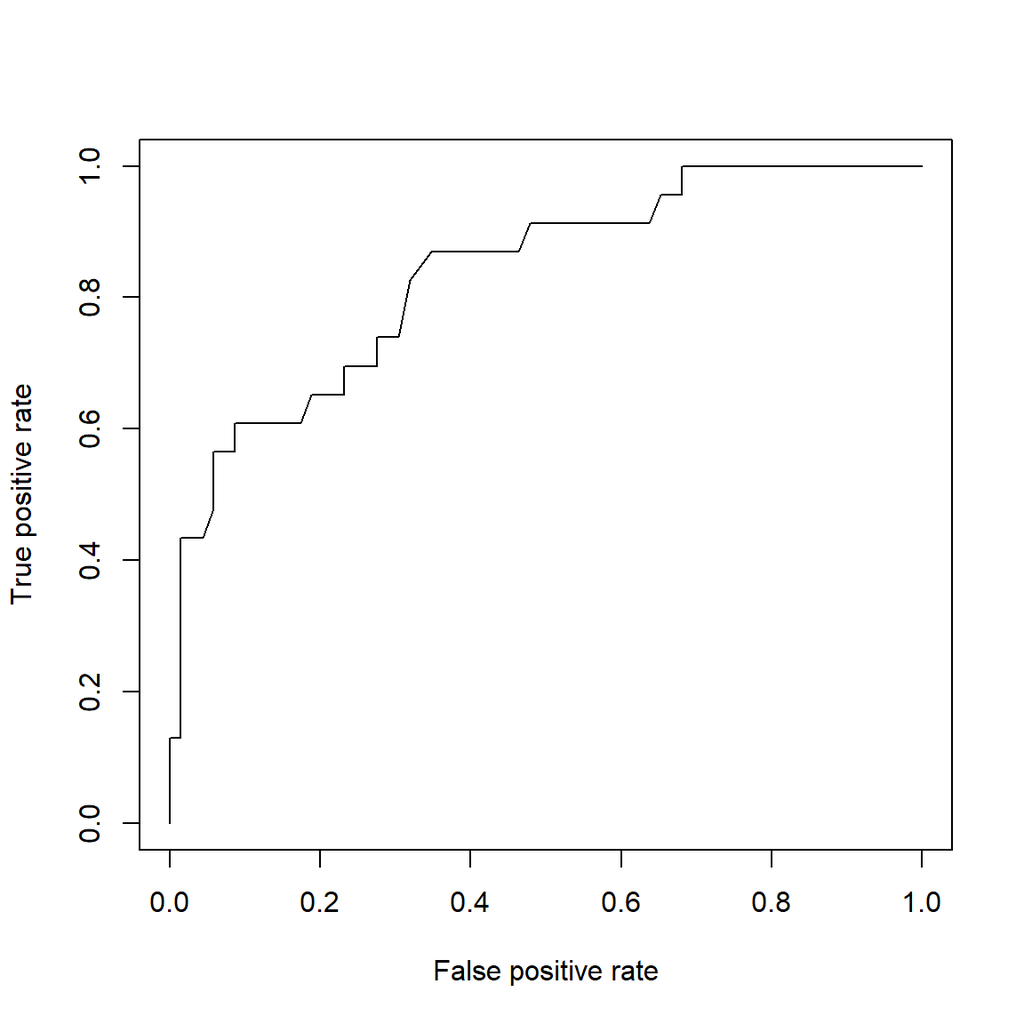

```r
ROCRpred = prediction(predictTrain, qualityTrain$PoorCare)
ROCRperf = performance(ROCRpred, "tpr", "fpr")
plot(ROCRperf)
```

We can add more visual effects to the ROC plot.

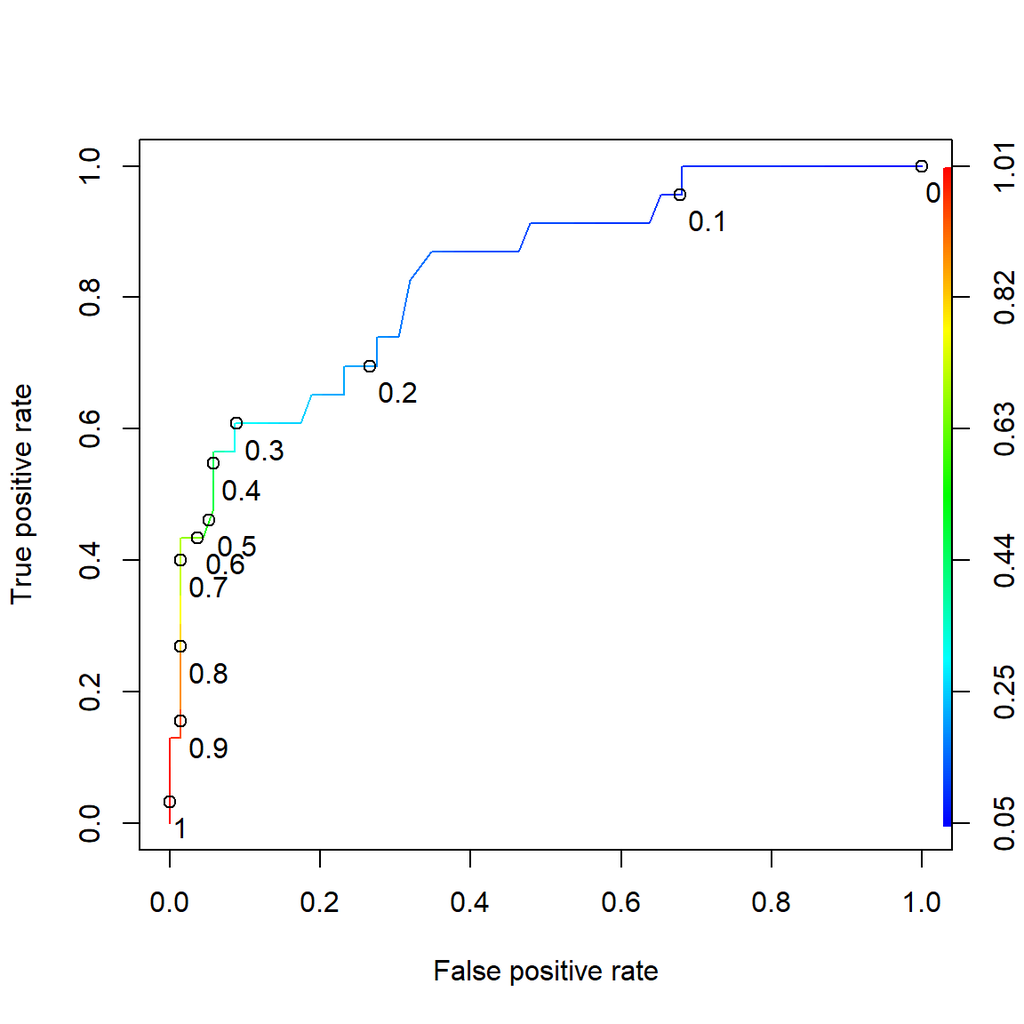

```r
plot(ROCRperf, colorize = TRUE, print.cutoffs.at = seq(0,1,0.1), text.adj = c(-0.2,1.7))
```

Now let us compute the area under the ROC curve (AUROC), or simply AUC.

```r
ROCRauc = performance(ROCRpred, "auc")
ROCRauc@y.values
```

```
## [[1]]
## [1] 0.8349086
```

There are other packages available for plotting ROC, and they offer different features that may be useful in some situations. For example, if we want to color the area under the ROC curve, we can use the ‘plot.roc’ function in the “pROC” package. Remember to install this package before the first use.

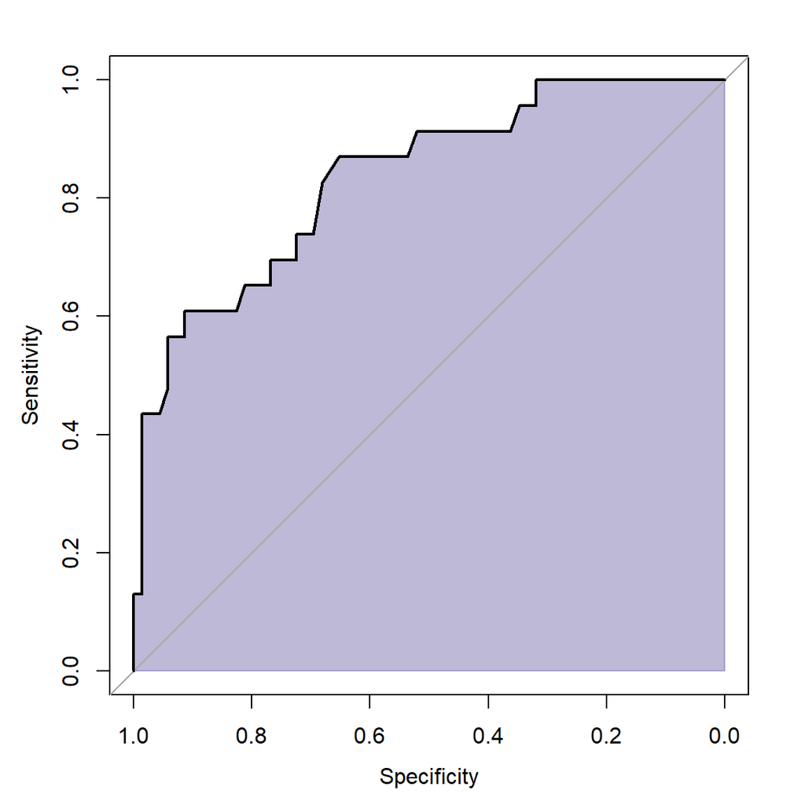

```r
library(pROC)
plot.roc(qualityTrain$PoorCare, predictTrain,
    auc.polygon = TRUE,
    auc.polygon.col=rgb(.35,0.31,0.61, alpha = 0.4),
    auc.polygon.border=rgb(.35,0.31,0.61, 0.4))
```

Note that by default, the x-axis for the ‘plot.roc’ function is specificity, which equals (1 - false-positive rate), and the numbers go from 1 to 0 from left to right.

# 6 Out-of-Sample Model Validation

Similarly, we can perform the out-of-sample test for our model using the test data set.

```r
predictTest = predict(QualityLog, type = "response", newdata = qualityTest)
conf03out = table(qualityTest$PoorCare, predictTest > 0.3)
conf03out
```

```
##
##     FALSE TRUE
##   0    27    2
##   1     6    4
```

The out-of-sample accuracy of the model with threshold 0.3 is 31/39 = 79.49%. We can also plot the out-of-sample ROC of the model and compute its out-of-sample AUC.

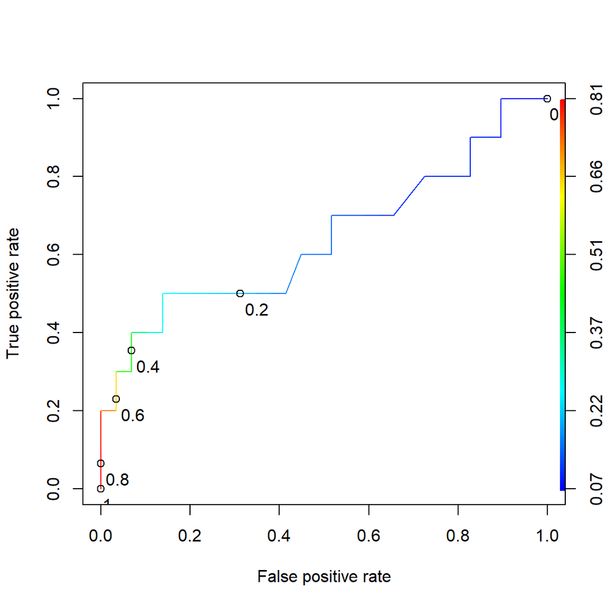

```r
ROCRpredTest = prediction(predictTest, qualityTest$PoorCare)
ROCRperfTest = performance(ROCRpredTest, "tpr", "fpr")
plot(ROCRperfTest, colorize = TRUE, print.cutoffs.at = seq(0,1,0.2), text.adj = c(-0.2,1.7))
```

# 7 Troubleshooting

If your package installation fails with the following error message:

```
Warning in install.packages :
  unable to access index for repository https://cran.rstudio.com/src/contrib:
  cannot open URL 'https://cran.rstudio.com/src/contrib/PACKAGES'
```

you may need to set a default CRAN mirror by typing the following command in your R Console:

```
options(repos = c(CRAN = "http://cran.rstudio.com"))
```